# WUP_04

Alma Andreasian

16 September 2021

# Introduction

The data is in the file GSScsv.csv and came from the 2018 General Social Survey. The question to answer is to resolve this hypothesis.  
$H_0$ There is no difference between the average score on the WORDSUM test and level of schooling DEGREE  
$H_a$ There is a significant difference in average score on the WORDSUM test between at least two levels of DEGREE

# Results

## Descriptive Results

### Graphical Descriptive Results

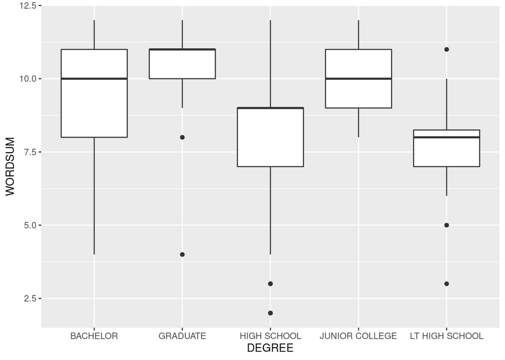

```r
basicCN <- ggplot(WordData,aes(x=DEGREE,y=WORDSUM))

basicCN + geom_boxplot()
```

```r
favstats(WORDSUM~DEGREE,data=WordData)
```

| DEGREE | min | Q1 | median | Q3 | max | mean | sd | n | missing |
| --- | --- | --- | --- | --- | --- | --- | --- | --- | --- |
| BACHELOR | 4 | 8 | 10 | 11.00 | 12 | 9.204545 | 2.052560 | 44 | 0 |
| GRADUATE | 4 | 10 | 11 | 11.00 | 12 | 10.095238 | 1.729299 | 21 | 0 |
| HIGH SCHOOL | 2 | 7 | 9 | 9.00 | 12 | 8.282353 | 2.234000 | 85 | 0 |
| JUNIOR COLLEGE | 8 | 9 | 10 | 11.00 | 12 | 9.916667 | 1.378954 | 12 | 0 |
| LT HIGH SCHOOL | 3 | 7 | 8 | 8.25 | 11 | 7.750000 | 1.949359 | 16 | 0 |

Numerical summary shows that the median of the graduates is the highest at 11 WORDSUM andthe mean is also the highest for them at 10.1. We can see that that base of the mean that there is a slight difference in WORDSUM between the education levels.

## Inferential Results

```r
model1 <- aov(WORDSUM~DEGREE,data=WordData)
summary.aov(model1)
```

```
##              Df Sum Sq Mean Sq F value   Pr(>F)
## DEGREE        4   97.8  24.445   5.729 0.000236 ***
## Residuals   173  738.1   4.267
## ---
## Signif. codes:  0 '***' 0.001 '**' 0.01 '*' 0.05 '.' 0.1 ' ' 1
```

The P value is very low at 0.000236. I rejet the null Hypothesis because the number is so low that the probability of getting the result we found is extremely low.

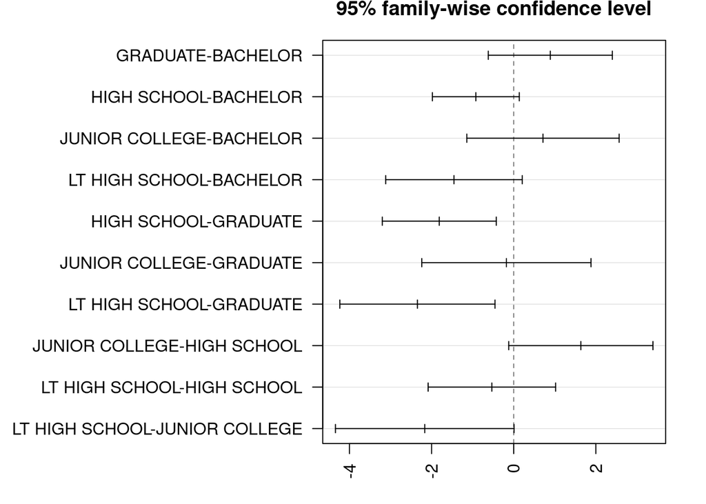

```r
#we specify the margins starting at the bottom and proceeding clockwise - thus 8.7 is the left side margin to hold the names of the factors
par(mar = c(3, 16, 2, 2))
plot(TukeyHSD(model1),las=2)
```

# Discussion and Conclusion

I reject the null hypothesis because P value was 0.000236, we found that there was a difference between Lt High school-Graduate and High school-Graduate.